# Machine Learning Project: Prediction of Performance of Exercise

January 28, 2016

## Background

Using devices such as Jawbone Up, Nike FuelBand, and Fitbit it is now possible to collect a large amount of data about personal activity relatively inexpensively. These type of devices are part of the quantified self movement - a group of enthusiasts who take measurements about themselves regularly to improve their health, to find patterns in their behavior, or because they are tech geeks. One thing that people regularly do is quantify how much of a particular activity they do, but they rarely quantify how well they do it.

In this project, we use data from accelerometers on the belt, forearm, arm, and dumbell of 6 participants who were asked to perform barbell lifts correctly and incorrectly in 5 different ways. We create model to predict the quality of the exercise. The data for this project come from this source: http://groupware.les.inf.puc-rio.br/har.

### Load package

```r
library(caret)
library(rpart)
library(e1071)
library(gbm)
library(plyr)
```

### Download Data

#### 1. Download training data set from https://d396qusza40orc.cloudfront.net/predmachlearn/pml-training.csv.

#### 2. Download test data set from http://d396qusza40orc.cloudfront.net/predmachlearn/pml-testing.csv.

In the raw data, there are values like NA, blanks and #DIV/0!. We treat them all as NAs when importing data.

```r
trainUrl <- "http://d396qusza40orc.cloudfront.net/predmachlearn/pml-training.csv"
testUrl <- "http://d396qusza40orc.cloudfront.net/predmachlearn/pml-testing.csv"
training <- read.csv(url(trainUrl), na.strings=c("NA","#DIV/0!",""))
testing <- read.csv(url(testUrl), na.strings=c("NA","#DIV/0!",""))
```

### Clean Data

#### 1. Remove Columns with Large Proportion of NAs.

```r
dim(training)
```

```
## [1] 19622   160
```

```r
dim(testing)
```

```
## [1]  20 160
```

The raw training data has 19622 rows and 160 columns. The raw testing data has 20 rows and 160 columns.

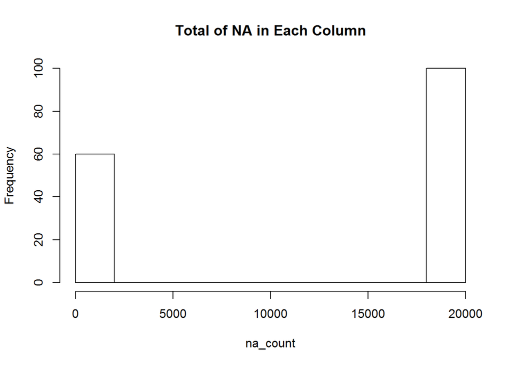

```r
na_count<-sapply(training, function(x) sum(length(which(is.na(x)))))
hist(na_count,main='Total of NA in Each Column')
```

```r
rmnatraining<-training[,which(na_count<5000)]
dim(rmnatraining)
```

```
## [1] 19622    60
```

#### 2. Remove Non-movement Variables

Based on the analysis requirements, we remove non-movement variables: x, user_name, raw_timestamp_part_1, raw_timestamp_part_2, cvtd_timestamp, new_window and num_window, which are column 1 to column 7.

```r
trainingdf<-rmnatraining[,-c(1:7)]
dim(trainingdf)
```

```
## [1] 19622    53
```

#### 3. Remove Near Zero Variance Variables

Let’s check the variance of the predictors with nearZeroVar function in R.

```r
nvrmx<-nearZeroVar(trainingdf,saveMetrics=TRUE)
nvrmx$zeroVar==TRUE
```

```
##  [1] FALSE FALSE FALSE FALSE FALSE FALSE FALSE FALSE FALSE FALSE FALSE
## [12] FALSE FALSE FALSE FALSE FALSE FALSE FALSE FALSE FALSE FALSE FALSE
## [23] FALSE FALSE FALSE FALSE FALSE FALSE FALSE FALSE FALSE FALSE FALSE
## [34] FALSE FALSE FALSE FALSE FALSE FALSE FALSE FALSE FALSE FALSE FALSE
## [45] FALSE FALSE FALSE FALSE FALSE FALSE FALSE FALSE FALSE
```

```r
nvrmx$nzv==TRUE
```

```
##  [1] FALSE FALSE FALSE FALSE FALSE FALSE FALSE FALSE FALSE FALSE FALSE
## [12] FALSE FALSE FALSE FALSE FALSE FALSE FALSE FALSE FALSE FALSE FALSE
## [23] FALSE FALSE FALSE FALSE FALSE FALSE FALSE FALSE FALSE FALSE FALSE
## [34] FALSE FALSE FALSE FALSE FALSE FALSE FALSE FALSE FALSE FALSE FALSE
## [45] FALSE FALSE FALSE FALSE FALSE FALSE FALSE FALSE FALSE
```

It seems none variables are constant or almost constant predictors across samples. We don’t remove any columns in this step.

#### 4. Remove Highly Related Variables

Let’s identify related predictors with correlation value greater than 0.75 and revome these variables.

```r
CorTraining<-cor(trainingdf[,-53])
summary(CorTraining[upper.tri(CorTraining)])
```

```
##      Min.   1st Qu.    Median      Mean   3rd Qu.      Max.
## -0.992000 -0.110100  0.002092  0.001790  0.092550  0.980900
```

```r
highcor<-findCorrelation(CorTraining,cutoff=.75)
FilteredTraining<-trainingdf[,-highcor]
CorFilTraining<-cor(FilteredTraining[,-32])
summary(CorFilTraining[upper.tri(CorFilTraining)])
```

```
##      Min.   1st Qu.    Median      Mean   3rd Qu.      Max.
## -0.607000 -0.103800  0.006527  0.003332  0.087530  0.736500
```

Now we have 32 columns for the training data set. We use the same variables for testing data set for prediction.

```r
testingcolnames<-colnames(FilteredTraining[,-32])
FilteredTesting<-testing[,testingcolnames]
dim(FilteredTesting)
```

```
## [1] 20 31
```

#### 5. Split Data for Cross Validation

We split the filtered training data set into two parts: one for creating model (70%) and the other for cross validation (30%).

```r
inTrain=createDataPartition(y=FilteredTraining$classe,p=0.7,list=FALSE)
mytraining=FilteredTraining[inTrain,]
mytesting=FilteredTraining[-inTrain,]
```

### Analyze and Predict Data

Since we need to classify the performance of the exercise, we use random forests and boosting with trees methods to analyze and predict data.

#### 1. Random Forests Modeling

```r
modfitrm<-train(classe~.,method="rf",data=mytraining)
predictrf<-predict(modfitrm,mytesting)
cmrf<-confusionMatrix(predictrf,mytesting$classe)
prerm<-predict(modfitrm,testing)
```

```r
cmrf
```

```
## Confusion Matrix and Statistics
##
##           Reference
## Prediction    A    B    C    D    E
##          A 1673    6    0    0    0
##          B    1 1127    9    0    0
##          C    0    6 1014   18    0
##          D    0    0    3  946    3
##          E    0    0    0    0 1079
##
## Overall Statistics
##
##                Accuracy : 0.9922
##                  95% CI : (0.9896, 0.9943)
##     No Information Rate : 0.2845
##     P-Value [Acc > NIR] : < 2.2e-16
##
##                   Kappa : 0.9901
##  Mcnemar's Test P-Value : NA
##
## Statistics by Class:
##
##                      Class: A Class: B Class: C Class: D Class: E
## Sensitivity            0.9994   0.9895   0.9883   0.9813   0.9972
## Specificity            0.9986   0.9979   0.9951   0.9988   1.0000
## Pos Pred Value         0.9964   0.9912   0.9769   0.9937   1.0000
## Neg Pred Value         0.9998   0.9975   0.9975   0.9964   0.9994
## Prevalence             0.2845   0.1935   0.1743   0.1638   0.1839
## Detection Rate         0.2843   0.1915   0.1723   0.1607   0.1833
## Detection Prevalence   0.2853   0.1932   0.1764   0.1618   0.1833
## Balanced Accuracy      0.9990   0.9937   0.9917   0.9901   0.9986
```

```r
prerm
```

```
##  [1] B A B A A E D B A A B C B A E E A B B B
## Levels: A B C D E
```

#### 2. Boosting with Trees Modeling

```r
modfitgbm<-train(classe~.,method="gbm",data=mytraining,verbose = FALSE) # Boosting with Trees Modeling
predictgbm<-predict(modfitgbm,mytesting)
cmgbm<-confusionMatrix(predictgbm,mytesting$classe)
pregbm<-predict(modfitrm,testing)
```

```r
cmgbm
```

```
## Confusion Matrix and Statistics
##
##           Reference
## Prediction    A    B    C    D    E
##          A 1637   42    0    2    3
##          B   24 1039   59    8   15
##          C    6   48  952   38   10
##          D    6    7   15  913   12
##          E    1    3    0    3 1042
##
## Overall Statistics
##
##                Accuracy : 0.9487
##                  95% CI : (0.9427, 0.9542)
##     No Information Rate : 0.2845
##     P-Value [Acc > NIR] : < 2.2e-16
##
##                   Kappa : 0.9351
##  Mcnemar's Test P-Value : 5.055e-07
##
## Statistics by Class:
##
##                      Class: A Class: B Class: C Class: D Class: E
## Sensitivity            0.9779   0.9122   0.9279   0.9471   0.9630
## Specificity            0.9888   0.9777   0.9790   0.9919   0.9985
## Pos Pred Value         0.9721   0.9074   0.9032   0.9580   0.9933
## Neg Pred Value         0.9912   0.9789   0.9847   0.9897   0.9917
## Prevalence             0.2845   0.1935   0.1743   0.1638   0.1839
## Detection Rate         0.2782   0.1766   0.1618   0.1551   0.1771
## Detection Prevalence   0.2862   0.1946   0.1791   0.1619   0.1782
## Balanced Accuracy      0.9834   0.9449   0.9534   0.9695   0.9808
```

```r
pregbm
```

```
##  [1] B A B A A E D B A A B C B A E E A B B B
## Levels: A B C D E
```

## Conclusion

We apply the random forests model to predict the testing data. The 20 predictions of the class for the testing data set are: B A B A A E D B A A B C B A E E A B B B.